# Week 3

Logistic Regression

COSTA DOS SANTOS David

2019-03-21 13:45:59

**Exercise 1**  
*Download the Social_Network_Ads dataset and import it into R.*

```r
mydata = read.csv("Social_Network_Ads.csv") #read csv file
summary(mydata )
```

```
##     User.ID            Gender         Age        EstimatedSalary
##  Min.   :15566689   Female:204   Min.   :18.00   Min.   : 15000
##  1st Qu.:15626764   Male  :196   1st Qu.:29.75   1st Qu.: 43000
##  Median :15694342                Median :37.00   Median : 70000
##  Mean   :15691540                Mean   :37.66   Mean   : 69743
##  3rd Qu.:15750363                3rd Qu.:46.00   3rd Qu.: 88000
##  Max.   :15815236                Max.   :60.00   Max.   :150000
##    Purchased
##  Min.   :0.0000
##  1st Qu.:0.0000
##  Median :0.0000
##  Mean   :0.3575
##  3rd Qu.:1.0000
##  Max.   :1.0000
```

**Exercise 2**  
*Explore and Describe the dataset (you can use str() and summary() functions, you can calculate and visualize the correlations, show some histograms, scatterplots, pie charts, etc..).*

```r
summary(mydata)
```

```
##     User.ID            Gender         Age        EstimatedSalary
##  Min.   :15566689   Female:204   Min.   :18.00   Min.   : 15000
##  1st Qu.:15626764   Male  :196   1st Qu.:29.75   1st Qu.: 43000
##  Median :15694342                Median :37.00   Median : 70000
##  Mean   :15691540                Mean   :37.66   Mean   : 69743
##  3rd Qu.:15750363                3rd Qu.:46.00   3rd Qu.: 88000
##  Max.   :15815236                Max.   :60.00   Max.   :150000
##    Purchased
##  Min.   :0.0000
##  1st Qu.:0.0000
##  Median :0.0000
##  Mean   :0.3575
##  3rd Qu.:1.0000
##  Max.   :1.0000
```

```r
str(mydata)
```

```
## 'data.frame':    400 obs. of  5 variables:
##  $ User.ID        : int  15624510 15810944 15668575 15603246 15804002 15728773 15598044 15694829 15600575 15727311 ...
##  $ Gender         : Factor w/ 2 levels "Female","Male": 2 2 1 1 2 2 1 1 2 1 ...
##  $ Age            : num  19 35 26 27 19 27 27 32 25 35 ...
##  $ EstimatedSalary: num  19000 20000 43000 57000 76000 58000 84000 150000 33000 65000 ...
##  $ Purchased      : int  0 0 0 0 0 0 0 1 0 0 ...
```

```r
cor(mydata$Age,mydata$Purchased)
```

```
## [1] 0.6224542
```

We study a population of 204 female and 196 male, aged from 18 to 60 with a mean of 37 years old. Their salary is variating between 15000 and 150000 with a mean of 69742. 35,75% people bought the produce from the ad.

**Exercise 3**  
*Now we are going to split the dataset into training set and test set. Last week we did it manually. From now on we will split it randomly, you can use this code (after undestanding it of course):*

```r
library(caTools) # install it first in the console
set.seed(123)
# we use the function set.seed() with the same seed number
# to randomly generate the same values, you already know that right?
#and you know why we want to generate the same values, am I wrong?
split=sample.split(mydata$Purchased,SplitRatio=0.75)
# here we chose the SplitRatio to 75% of the dataset,
# and 25% for the test set.
training_set = subset(mydata, split == TRUE)
# we use subset to split the dataset
test_set = subset(mydata, split == FALSE)
dim(test_set)
```

```
## [1] 100   5
```

```r
#size training set
dim(training_set)
```

```
## [1] 300   5
```

**Exercise 4**  
*Scale the input variables in both training set and test set. Do you know what is scaling? Explain it one sentence.* *Scaling is used to center and/or scale the columns of a numeric matrix.*

```r
#scale(mydata$User.ID, center = TRUE, scale = TRUE)
#scale(mydata$Age, center = TRUE, scale = TRUE)
#scale(mydata$EstimatedSalary, center = TRUE, scale = TRUE)
```

**Exercise 5**  
*Now fit a simple logistic regression model of Purchased in function of Age.*

```r
model=glm(formula = Purchased ~ Age, family = binomial, data = training_set)
model
```

```
##
## Call:  glm(formula = Purchased ~ Age, family = binomial, data = training_set)
##
## Coefficients:
## (Intercept)          Age
##     -8.0630       0.1904
##
## Degrees of Freedom: 299 Total (i.e. Null);  298 Residual
## Null Deviance:       390.9
## Residual Deviance: 252.1     AIC: 256.1
```

**Exercise 6**  
*As you saw in the Logistic Regression chapter and in the previous question, we choose argument family to be binomial when we use the function glm. Explain why!*  
We must pass in the argument family=binomial in order to tell R to run a logistic regression rather than some other type of generalized linear model. And because Purchased can only be 0 or 1.

**Exercise 9**  
*What is the value of AIC of the model?*

```r
AIC(model)
```

```
## [1] 256.109
```

**Exercise 10**  
*Plot Purchased in function of Age and add the curve of the obtained logistic regression model.*

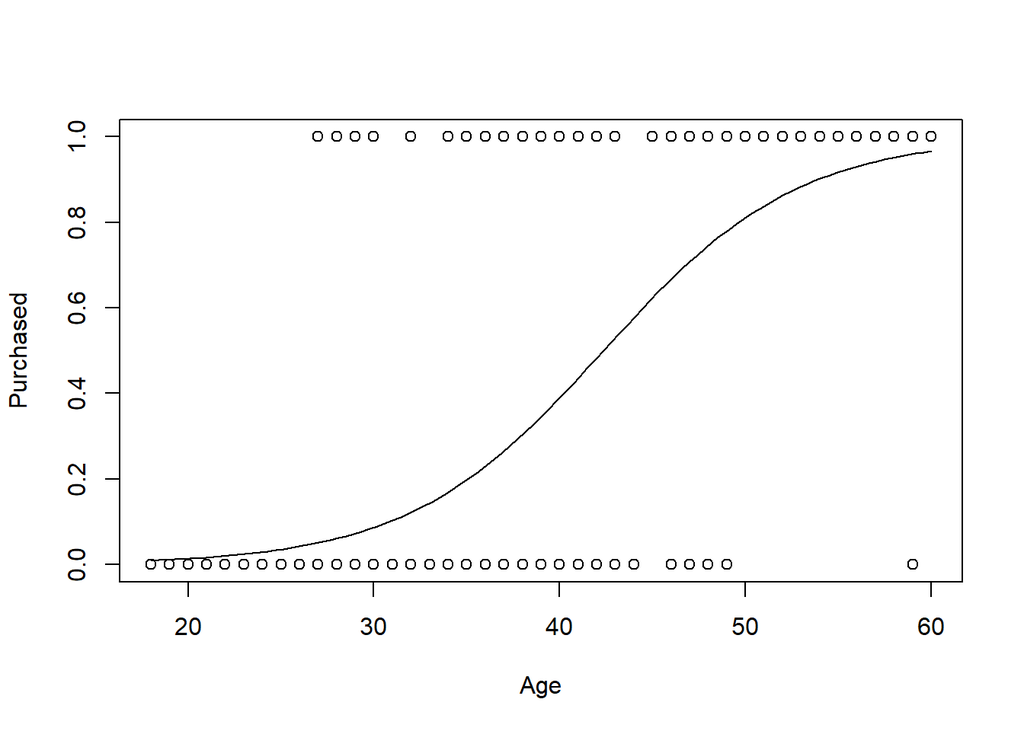

```r
plot(training_set$Age,training_set$Purchased,xlab="Age",ylab="Purchased")
g=glm(Purchased~Age,family=binomial,training_set)
curve(predict(g,data.frame(Age=x),type="response"),add=TRUE)
```

**Exercise 11**  
*Now let us take another feature into account in the model. Fit a logistic regression model of purchasing the product in function of the age of a user and its salary.*

```r
g=glm(Purchased~Age+EstimatedSalary,family=binomial,training_set)
summary(g)
```

```
##
## Call:
## glm(formula = Purchased ~ Age + EstimatedSalary, family = binomial,
##     data = training_set)
##
## Deviance Residuals:
##     Min       1Q   Median       3Q      Max
## -3.0753  -0.5235  -0.1161   0.3224   2.3977
##
## Coefficients:
##                   Estimate Std. Error z value Pr(>|z|)
## (Intercept)     -1.343e+01  1.665e+00  -8.070 7.05e-16 ***
## Age              2.517e-01  3.309e-02   7.606 2.83e-14 ***
## EstimatedSalary  3.980e-05  6.639e-06   5.996 2.03e-09 ***
## ---
## Signif. codes:  0 '***' 0.001 '**' 0.01 '*' 0.05 '.' 0.1 ' ' 1
##
## (Dispersion parameter for binomial family taken to be 1)
##
##     Null deviance: 390.89  on 299  degrees of freedom
## Residual deviance: 199.78  on 297  degrees of freedom
## AIC: 205.78
##
## Number of Fisher Scoring iterations: 6
```

**Exercise 12**  
*Are the predictors significant to the new model?*  
The AIC is even lower so yes, the model got better: the predictors are significant.